# KPI_analysis

[figure not shown]

##### The KPI analysis phase focuses on evaluating key business metrics such as sales, returns, revenue, orders, and customer activity to measure overall performance. By analyzing these indicators, the project identifies trends, efficiency gaps, and the impact of returns on profitability. This helps in making data-driven decisions to improve operations, customer satisfaction, and business growth.

## 🎯 KPI Analysis

1. Analyze Monthly KPI
2. Analyze Core KPIs
- Visualize Total Sales Qty
- Visualize Total Return Qty
- Visualize Return Rate(%)
- Visualize Total Orders
- Visualize Total Customers
- Visualize Gross Revenue
3. Customer Return Ratio
4. Customer Lifetime Value
5. KPI Summary

## Import Various Modules

```python
import pandas as pd
import numpy as np
import matplotlib.pyplot as plt
import seaborn as sns
```

## Load Datasets

```python
df = pd.read_csv("clean_retail_online_sales.csv")

print(df.shape)
df.head()
```

```
(461360, 9)
```

|  | InvoiceNo | StockCode | Description | Quantity | InvoiceDate | UnitPrice | CustomerID | Country | Revenue |
| --- | --- | --- | --- | --- | --- | --- | --- | --- | --- |
| 0 | 536365 | 85123A | WHITE HANGING HEART T-LIGHT HOLDER | 6 | 2010-12-01 08:26:00 | 2.55 | 17850 | United Kingdom | 15.30 |
| 1 | 536365 | 71053 | WHITE METAL LANTERN | 6 | 2010-12-01 08:26:00 | 3.39 | 17850 | United Kingdom | 20.34 |
| 2 | 536365 | 84406B | CREAM CUPID HEARTS COAT HANGER | 8 | 2010-12-01 08:26:00 | 2.75 | 17850 | United Kingdom | 22.00 |
| 3 | 536365 | 84029G | KNITTED UNION FLAG HOT WATER BOTTLE | 6 | 2010-12-01 08:26:00 | 3.39 | 17850 | United Kingdom | 20.34 |
| 4 | 536365 | 84029E | RED WOOLLY HOTTIE WHITE HEART. | 6 | 2010-12-01 08:26:00 | 3.39 | 17850 | United Kingdom | 20.34 |

## Basic Data Overview

```python
df.shape
df.info()
df.describe()
```

```
<class 'pandas.core.frame.DataFrame'>
RangeIndex: 461360 entries, 0 to 461359
Data columns (total 9 columns):
 #   Column       Non-Null Count   Dtype
---  ------       --------------   -----
 0   InvoiceNo    461360 non-null  int64
 1   StockCode    461360 non-null  object
 2   Description  461360 non-null  object
 3   Quantity     461360 non-null  int64
 4   InvoiceDate  461360 non-null  object
 5   UnitPrice    461360 non-null  float64
 6   CustomerID   461360 non-null  int64
 7   Country      460897 non-null  object
 8   Revenue      461360 non-null  float64
dtypes: float64(2), int64(3), object(4)
memory usage: 31.7+ MB
```

|  | InvoiceNo | Quantity | UnitPrice | CustomerID | Revenue |
| --- | --- | --- | --- | --- | --- |
| count | 461360.000000 | 461360.000000 | 461360.000000 | 461360.000000 | 461360.000000 |
| mean | 560099.527653 | 6.001218 | 2.592812 | 15309.244783 | 11.701573 |
| std | 13412.859925 | 9.565581 | 1.931119 | 1477.478554 | 13.171301 |
| min | 536365.000000 | -990.000000 | 0.000000 | 12347.000000 | -0.000000 |
| 25% | 548151.000000 | 1.000000 | 1.250000 | 14415.000000 | 3.300000 |
| 50% | 560826.000000 | 3.000000 | 2.080000 | 15287.000000 | 8.200000 |
| 75% | 571937.000000 | 10.000000 | 3.750000 | 16293.000000 | 15.900000 |
| max | 581587.000000 | 26.000000 | 8.330000 | 18287.000000 | 215.540000 |

## Split Data

```python
df_sales = df[df["Quantity"] > 0].copy()
df_returns = df[df["Quantity"] < 0].copy()
```

## Feature Setup

```python
# Convert date column
df["InvoiceDate"] = pd.to_datetime(df["InvoiceDate"])

# Create YearMonth column
df["YearMonth"] = df["InvoiceDate"].dt.to_period("M")
```

## 1) Monthly KPI

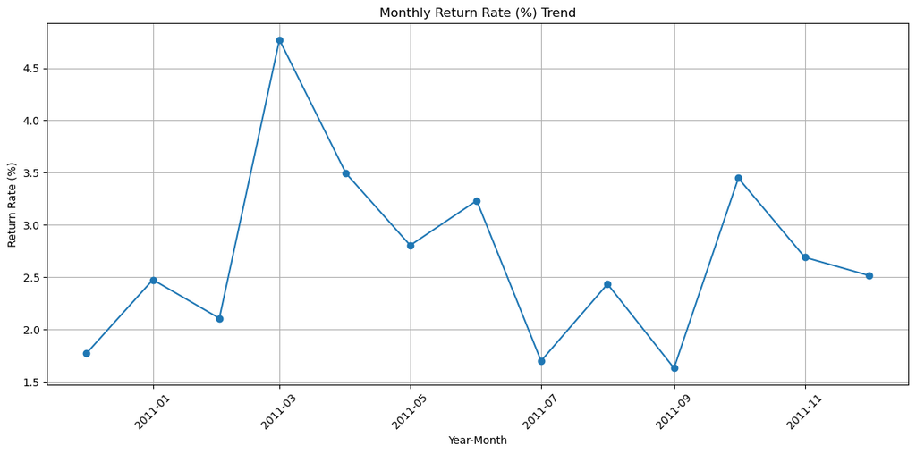

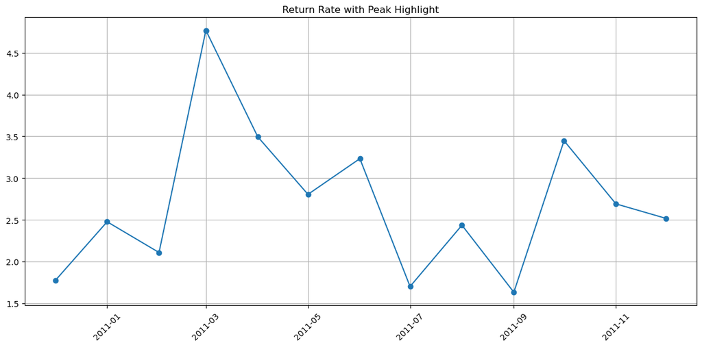

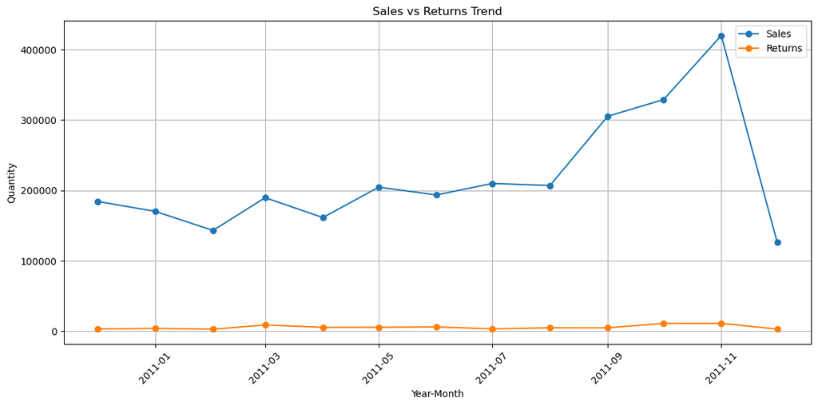

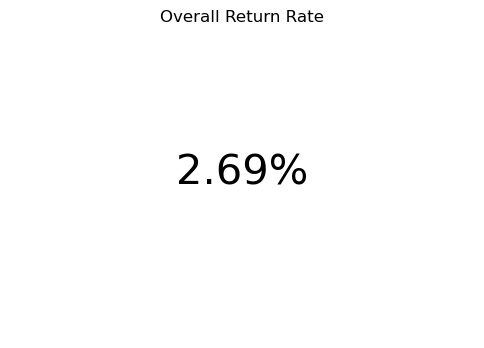

```python
# Monthly KPIs
monthly_sales = df_sales.groupby("YearMonth")["Quantity"].sum()
monthly_returns = df_returns.groupby("YearMonth")["Quantity"].sum().abs()

monthly_return_rate = (monthly_returns / monthly_sales) * 100

# datetime index
monthly_return_rate.index = monthly_return_rate.index.to_timestamp()
monthly_sales.index = monthly_sales.index.to_timestamp()
monthly_returns.index = monthly_returns.index.to_timestamp()

plt.figure(figsize=(12,6))

plt.plot(
    monthly_return_rate.index,
    monthly_return_rate.values,
    marker='o'
)

plt.title("Monthly Return Rate (%) Trend")
plt.xlabel("Year-Month")
plt.ylabel("Return Rate (%)")

plt.xticks(rotation=45)
plt.grid(True)

plt.tight_layout()
plt.show()


# Highlight Peak Month

peak_month = monthly_return_rate.idxmax()
peak_value = monthly_return_rate.max()

plt.figure(figsize=(12,6))

plt.plot(monthly_return_rate.index, monthly_return_rate.values, marker='o')
plt.scatter(peak_month, peak_value)

plt.title("Return Rate with Peak Highlight")
plt.xticks(rotation=45)
plt.grid(True)

plt.tight_layout()
plt.show()


# Sales vs Returns

plt.figure(figsize=(12,6))

plt.plot(monthly_sales.index, monthly_sales.values, marker='o', label="Sales")
plt.plot(monthly_returns.index, monthly_returns.values, marker='o', label="Returns")

plt.title("Sales vs Returns Trend")
plt.xlabel("Year-Month")
plt.ylabel("Quantity")

plt.legend()
plt.xticks(rotation=45)
plt.grid(True)

plt.tight_layout()
plt.show()

# Overall KPI

overall_return_rate = (monthly_returns.sum() / monthly_sales.sum()) * 100

plt.figure(figsize=(6,4))
plt.text(0.5, 0.5, f"{overall_return_rate:.2f}%", fontsize=30, ha='center')
plt.title("Overall Return Rate")
plt.axis('off')

plt.show()
```

Inference

- The monthly return rate reflects the proportion of returned items relative to total sales, serving as a key indicator of product performance and customer satisfaction
- Fluctuations in return rate across months highlight potential seasonal trends or product-related issues that require further investigation

## 2) Core KPIs

i) Total Sales Quantity

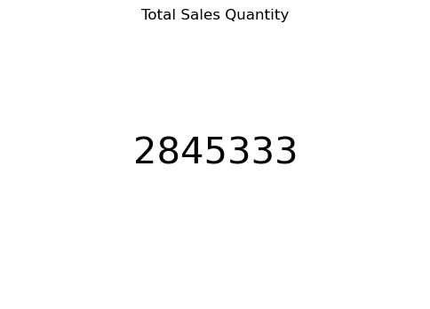

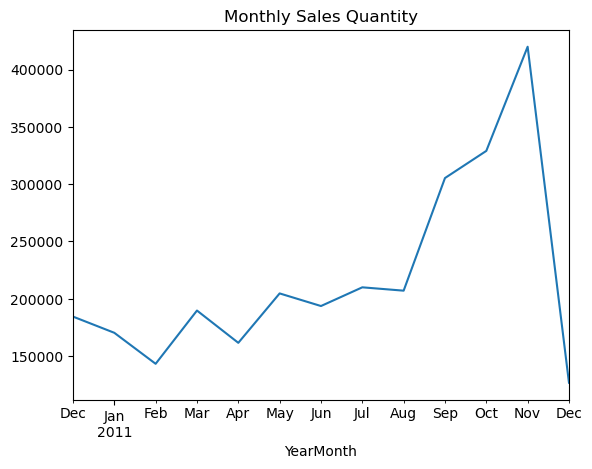

```python
total_sales_qty = df_sales["Quantity"].sum()

plt.figure(figsize=(6,4))
plt.text(0.5, 0.5, f"{total_sales_qty}", fontsize=30, ha='center')
plt.title("Total Sales Quantity")
plt.axis('off')

plt.show()

df_sales.groupby("YearMonth")["Quantity"].sum().plot(title="Monthly Sales Quantity")
```

Inference

- The total sales quantity represents the overall volume of products sold, indicating the business’s transaction scale and demand level
- Higher sales volume reflects strong customer demand and effective product performance

ii) Total Return Quantity

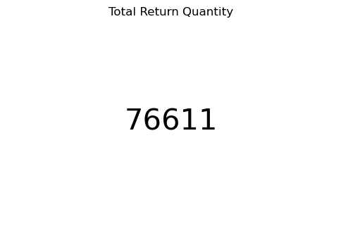

```
np.float64(2.6925143735372976)
```

```python
total_return_qty = df_returns["Quantity"].abs().sum()

plt.figure(figsize=(6,4))
plt.text(0.5, 0.5, f"{total_return_qty}", fontsize=30, ha='center')
plt.title("Total Return Quantity")
plt.axis('off')

plt.show()
(total_return_qty / total_sales_qty) * 100
```

Inference

- The total return quantity represents the overall volume of returned products, indicating potential product or service issues
- A high return volume may reflect quality concerns, incorrect product expectations, or operational inefficiencies

iii) Return Rate (%)

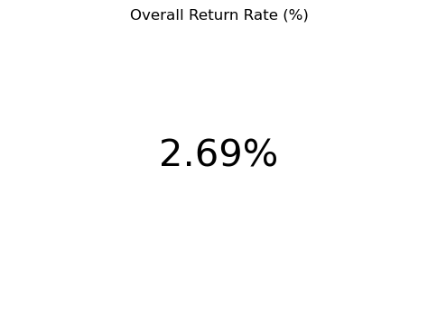

```python
return_rate = (total_return_qty / total_sales_qty) * 100

plt.figure(figsize=(6,4))
plt.text(0.5, 0.5, f"{return_rate:.2f}%", fontsize=30, ha='center')
plt.title("Overall Return Rate (%)")
plt.axis('off')

plt.show()
```

Inference

- The return rate indicates the percentage of sold products that were returned, serving as a key measure of product quality and customer satisfaction
- A higher return rate suggests potential issues in product performance, pricing, or customer expectations

iv) Total Orders

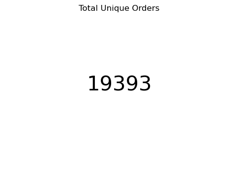

```
146.71958954261848
```

```python
total_orders = df["InvoiceNo"].nunique()

plt.figure(figsize=(6,4))
plt.text(0.5, 0.5, f"{total_orders}", fontsize=30, ha='center')
plt.title("Total Unique Orders")
plt.axis('off')

plt.show()

avg_items_per_order = total_sales_qty / total_orders
print(avg_items_per_order)
```

Inference

- The total number of unique orders represents the overall transaction volume, reflecting customer activity and business performance
- A higher number of orders indicates strong customer engagement and consistent demand

v) Total Customers

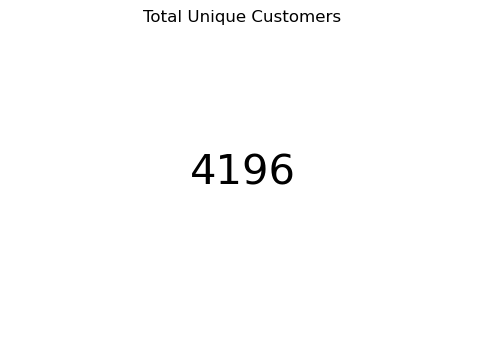

```
4.621782650142993
```

```python
total_customers = df["CustomerID"].nunique()

plt.figure(figsize=(6,4))
plt.text(0.5, 0.5, f"{int(total_customers)}", fontsize=30, ha='center')
plt.title("Total Unique Customers")
plt.axis('off')

plt.show()

orders_per_customer = total_orders / total_customers
print(orders_per_customer)
```

Inference

- The total number of unique customers reflects the size of the customer base and overall market reach
- A higher customer count indicates strong acquisition and business growth potential

vi) Gross Revenue

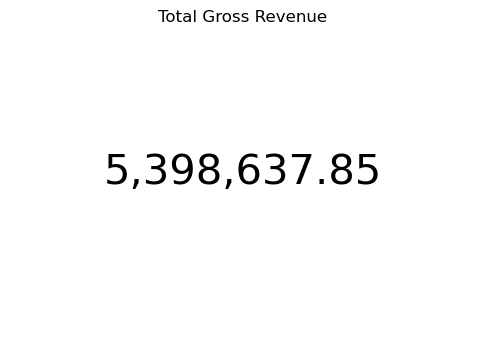

```
278.38074841437634
```

```python
gross_revenue = df_sales["Revenue"].sum()

plt.figure(figsize=(6,4))
plt.text(0.5, 0.5, f"{gross_revenue:,.2f}", fontsize=30, ha='center')
plt.title("Total Gross Revenue")
plt.axis('off')

plt.show()

avg_order_value = gross_revenue / total_orders
print(avg_order_value)
```

Inference

- The gross revenue represents the total income generated from sales, reflecting overall business performance and financial health
- Higher revenue indicates strong product demand and effective pricing strategy

## 3) Customer Return Ratio

[figure not shown]

```python
# Sales quantity per customer
sales_cust = df[df["Quantity"] > 0] \
.groupby("CustomerID")["Quantity"].sum()

# Return quantity per customer
return_cust = df[df["Quantity"] < 0] \
.groupby("CustomerID")["Quantity"].sum().abs()

# Align and calculate ratio
customer_return_ratio = (return_cust / sales_cust).fillna(0)
top_customers = customer_return_ratio.sort_values(ascending=False).head(10).reset_index()

plt.figure(figsize=(10,6))
sns.barplot(
    data=top_customers,
    x="Quantity",
    y="CustomerID"
)

plt.title("Top 10 Customers by Return Ratio")
plt.xlabel("Return Ratio")
plt.ylabel("Customer")

plt.tight_layout()
plt.show()
```

## 4) Customer Lifetime Value

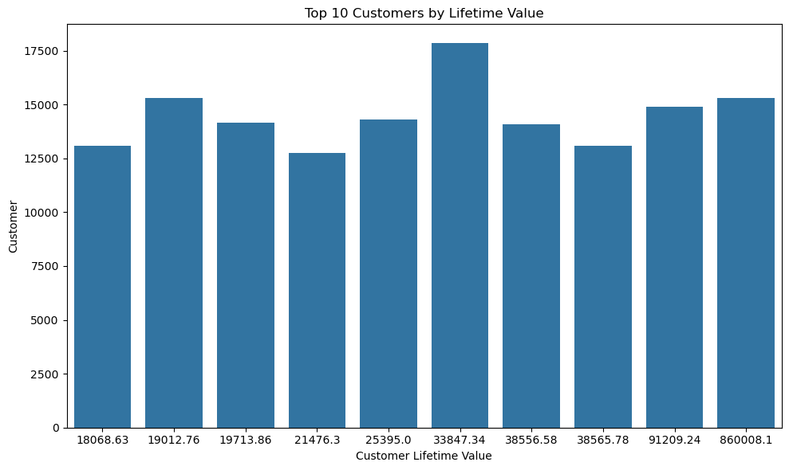

```
count      4196.000000
mean       1286.615313
std       13464.372798
min           1.900000
25%         218.070000
50%         497.810000
75%        1193.590000
max      860008.100000
Name: Revenue, dtype: float64
```

```python
customer_value = df.groupby("CustomerID")["Revenue"].sum()

top_customers = customer_value.sort_values(ascending=False).head(10).reset_index()

plt.figure(figsize=(10,6))
sns.barplot(
    data=top_customers,
    x="Revenue",
    y="CustomerID"
)

plt.title("Top 10 Customers by Lifetime Value")
plt.xlabel("Customer Lifetime Value")
plt.ylabel("Customer")

plt.tight_layout()
plt.show()

customer_value.describe()
```

Inference

- Customer lifetime value represents the total revenue generated by each customer, helping identify high-value customers contributing most to business revenue
- A small group of customers typically drives a significant portion of total revenue, highlighting opportunities for targeted retention strategies

## 5) KPI Summary

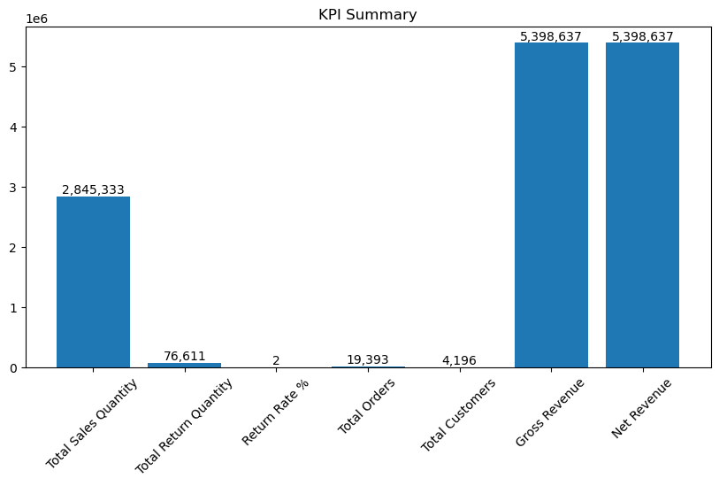

|  | KPI | Value |
| --- | --- | --- |
| 0 | Total Sales Quantity | 2845333.0 |
| 1 | Total Return Quantity | 76611.0 |
| 2 | Return Rate % | 3.0 |
| 3 | Total Orders | 19393.0 |
| 4 | Total Customers | 4196.0 |
| 5 | Gross Revenue | 5398638.0 |
| 6 | Net Revenue | 5398638.0 |

```python
kpi = {
    "Total Sales Quantity": total_sales_qty,
    "Total Return Quantity": total_return_qty,
    "Return Rate %": return_rate,
    "Total Orders": total_orders,
    "Total Customers": total_customers,
    "Gross Revenue": gross_revenue,
    "Net Revenue": net_revenue
}

plt.figure(figsize=(10,5))
bars = plt.bar(kpi_df["KPI"], kpi_df["Value"])

for bar in bars:
    yval = bar.get_height()
    plt.text(bar.get_x() + bar.get_width()/2, yval, f'{int(yval):,}',
             ha='center', va='bottom')

plt.xticks(rotation=45)
plt.title("KPI Summary")
plt.show()

kpi_df = pd.DataFrame(kpi.items(), columns=["KPI", "Value"])
kpi_df.round()
```

Inference

- The KPI summary provides a consolidated view of business performance across sales, returns, customers, and revenue
- It highlights key operational metrics and helps identify areas impacting profitability and customer behavior